Author- Geike De Sloover # Overview

If you want to do correction of instance segmentation of pointclouds were you **ran RayCloudTools (or other segmentation) yourself, you can skip this step** and use the RayCloudTools generated leftover pointcloud.

# Methods

## 1. Prepare the Point Clouds

### 1.a Select the Plot (20 m Buffer, 1 cm ds)

Follow [Part 4 of the general RiSCAN PRO manual](https://github.com/qforestlab/riscan-general/blob/main/4_select_plot_point_cloud.md) to create a 20 m buffered plot at 1 cm downsampling.

### 1.b Import Point Clouds into RiSCAN PRO

1. In the RiSCAN PRO project of the plot, navigate to `SCANS` and right click on it. Create a new scanposition,

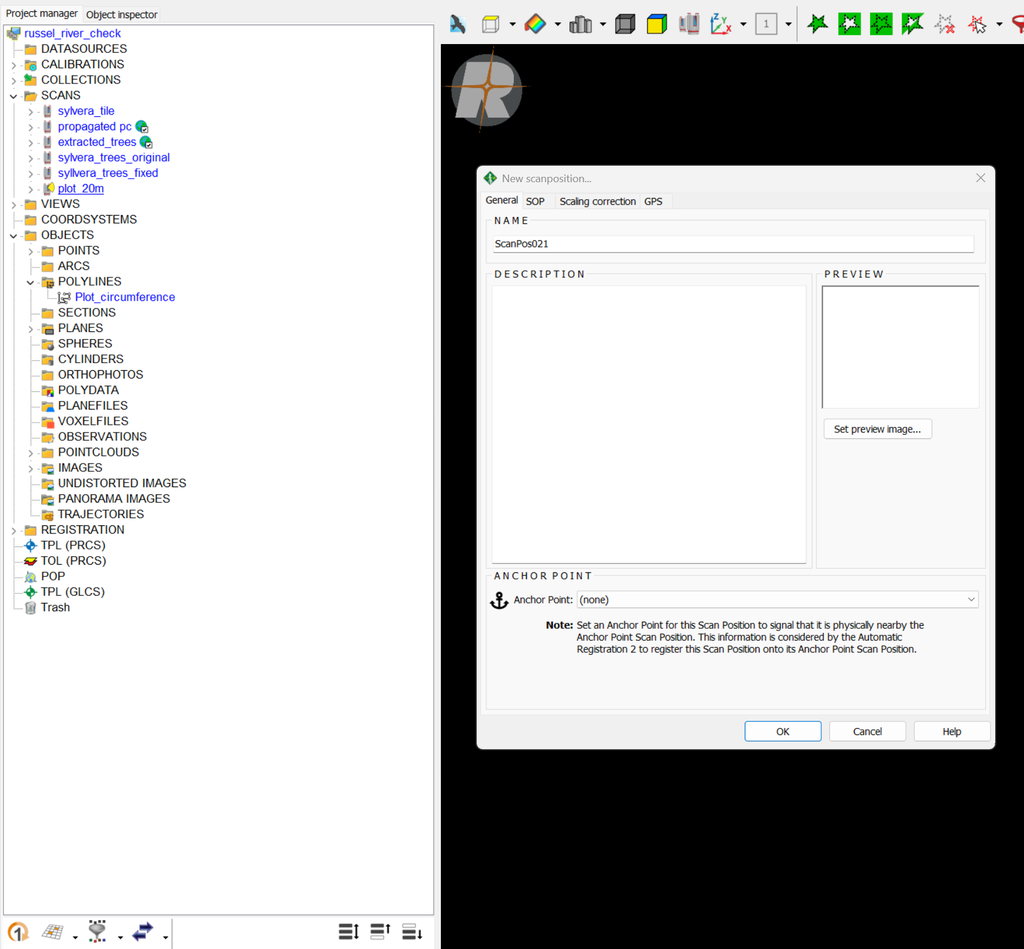

2. Import the desired point clouds (one or multiple) into this scanposition. `Scanposition>Pointclouds` –> right click and **import**.
3. Ensure you select the correct Coordinate Reference System (CRS) during import.

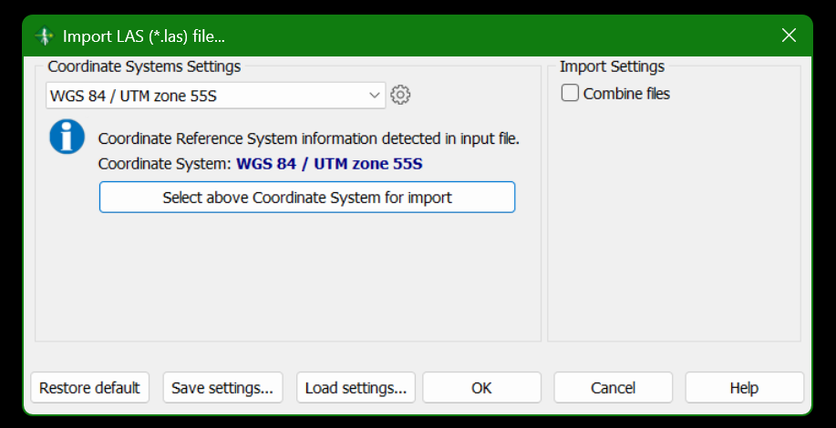

### 1.c Align the segmented Point Clouds to the Plot

1. Use SOP matrix (transformation matrix as a .DAT file) to align the segmented point clouds to the plot. Import the matrix by navigating to the scanposition SOP attributes, right click the matrix and select import. (There is also a lot of info on this in the general RiSCAN PRO manual).
2. Verify the alignment visually. If it is incorrect:
   - Run automatic registration with the `on failure` setting on.
   - Adjust the pointclouds manually on failure, until the fit is satisfactory
   - After the automatic registration, also run MSA and MSA2 for ultimate precision.
3. Once one (or a few) point cloud(s) is(are) correctly aligned, export the validated SOP matrix.
4. Import all point clouds and apply this SOP matrix for batch alignment.
5. Finally, export all aligned point clouds with the correct positions.

## 2. Run the Propagation Script

1. Clone or navigate to the [treeseg_propagation repository](https://github.com/qforestlab/treeseg_propagation).
2. Review the instructions in the README.
3. The script you need for this propagation is `tree_extraction.py` ([source link](https://github.com/qforestlab/treeseg_propagation/blob/master/tree_extraction.py)). If you need only a leftover pointcloud and your individual tree pointclouds are good quality and filtered to your liking, you can run `propagate_predictions.py`.
4. Set up a Python virtual environment and install the required packages.
5. Run the script.
6. Expect the process to take **1–2 hours** for one plot.

## 3. Select Trees within the AOI (for example-40 × 90 m)

Run all scripts **in order** from the [plot_selection repository](https://github.com/qforestlab/plot_selection) to extract the trees that fall inside the 40 × 90 m AOI.